# Nematode Diversity standardized by 80.8% sample coverage

Wei, C.-L., Liao, J.-X.

2020-04-30

# Reguired package

```r
library(nema)
library(iNEXT)
library(ggplot2)
library(reshape2)
library(vegan)
library(plyr)
library(viridis)
library(doBy)
library(cowplot)
library(knitr)
library(nlme)
library(MuMIn)
```

# ggplot theme setting

```r
large <- theme(legend.title = element_text(size=15),
        legend.text = element_text(size=15),
        axis.title = element_text(size=15),
        axis.text = element_text(size=15),
        strip.text = element_text(size=15))

rotate <- theme(axis.text.x = element_text(angle = 30, hjust=0.5))

no_strip <- theme(strip.background = element_rect(colour=NA, fill=NA),
                  strip.text = element_text(colour=NA))
```

# Preparing nematode and environmental data

Relative abundance of nematode species from 100 randomly slected individuals was scaled to the total nematode abundance in each sample.

```r
# Convert to species-by-sample matrix
b <- acast(nema_abund, Cruise+Station+Deployment+Tube+Subcore~Genus+Species, fill=0)
# Multiply the relative abundance by total abundance
#b <- ceiling(decostand(b, "total")*nema_total$Abundance)

# Match the trait data to the species-by-sample matrix
s <- nema_species[match(colnames(b), with(nema_species, paste(Genus, Species, sep="_"))),]

nema_cruise$Date <- factor(nema_cruise$Cruise, labels=c("2015-08", "2015-11"))
# Define depth zone
depth.bk <- c(200, 400, 600, 800, 1100)
depth.lab <- c("200-400", "400-600", "600-800", "800-1100")
nema_cruise$Zone <- cut(nema_cruise$Depth, breaks=depth.bk, labels=depth.lab)
```

# Abundance

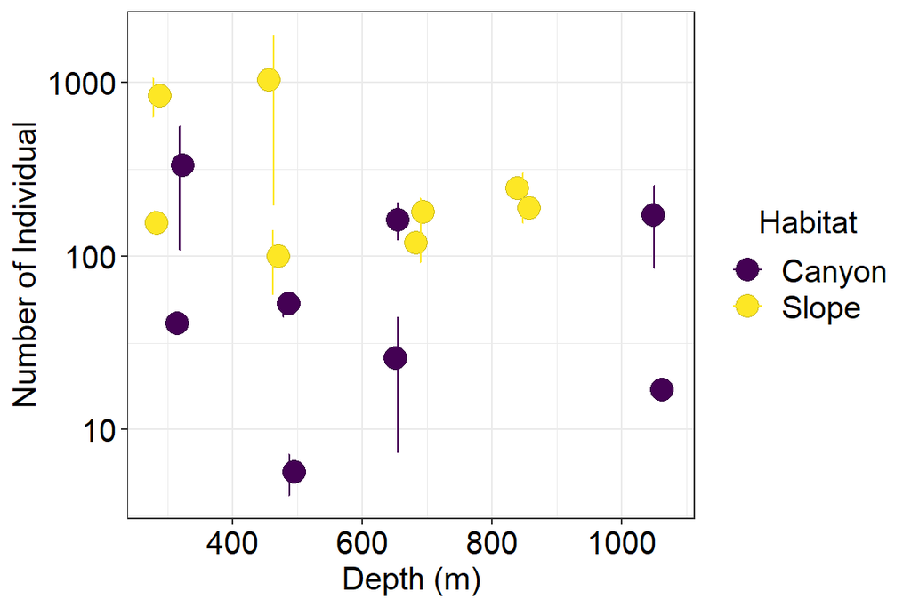

```r
abu <- summaryBy(Abundance~Cruise+Station+Deployment, nema_total, FUN=c(mean, sd, length))
names(abu)[-1:-3] <- c("Abund", "sd", "n")
id1 <- with(abu, paste(Cruise, Station, Deployment))
id2 <- with(nema_cruise, paste(Cruise, Station, Deployment))
abu <- cbind(abu, nema_cruise[match(id1, id2), -3:-5])

ggplot(data=abu,
       aes(x=Depth, y=Abund, ymin=Abund-sd, ymax=Abund+sd, colour=Habitat))+
  geom_point(aes(fill=Habitat), pch=21, colour=gray(0, 0.2), size=5,
                  position=position_jitter(width=10))+
  geom_errorbar()+
  labs(x="Depth (m)", y="Number of Individual")+
  scale_fill_viridis(discrete = TRUE)+
  scale_color_viridis(discrete = TRUE)+
  scale_y_log10()+
  theme_bw() %+replace% large
```

```r
# Linear regression
hl <- splitBy(~Habitat, abu)
lapply(hl, FUN=function(x)summary(lm(log10(Abund)~Depth, data=x)))
```

```
## $Canyon
##
## Call:
## lm(formula = log10(Abund) ~ Depth, data = x)
##
## Residuals:
##     Min      1Q  Median      3Q     Max
## -0.9773 -0.3273 -0.0743  0.5210  0.7714
##
## Coefficients:
##               Estimate Std. Error t value Pr(>|t|)
## (Intercept)  1.7921647  0.5573392   3.216   0.0182 *
## Depth       -0.0001264  0.0008106  -0.156   0.8812
## ---
## Signif. codes:  0 '***' 0.001 '**' 0.01 '*' 0.05 '.' 0.1 ' ' 1
##
## Residual standard error: 0.6346 on 6 degrees of freedom
## Multiple R-squared:  0.004039,   Adjusted R-squared:  -0.162
## F-statistic: 0.02433 on 1 and 6 DF,  p-value: 0.8812
##
##
## $Slope
##
## Call:
## lm(formula = log10(Abund) ~ Depth, data = x)
##
## Residuals:
##      Min       1Q   Median       3Q      Max
## -0.45214 -0.27533 -0.01458  0.20630  0.56582
##
## Coefficients:
##               Estimate Std. Error t value Pr(>|t|)
## (Intercept)  2.7130420  0.3804968    7.13 0.000383 ***
## Depth       -0.0005616  0.0006242   -0.90 0.402926
## ---
## Signif. codes:  0 '***' 0.001 '**' 0.01 '*' 0.05 '.' 0.1 ' ' 1
##
## Residual standard error: 0.3833 on 6 degrees of freedom
## Multiple R-squared:  0.1189, Adjusted R-squared:  -0.02797
## F-statistic: 0.8095 on 1 and 6 DF,  p-value: 0.4029
```

```r
# Linear Mixed-Effects Models
f <- lme(fixed = log10(Abund) ~ Habitat*Depth, random = ~1|Cruise, data=abu, method = "REML", weights=varIdent(form=~1|Cruise))
summary(f)
```

```
## Linear mixed-effects model fit by REML
##  Data: abu
##        AIC      BIC    logLik
##   62.31816 65.71251 -24.15908
##
## Random effects:
##  Formula: ~1 | Cruise
##          (Intercept) Residual
## StdDev: 1.658777e-05 0.333253
##
## Variance function:
##  Structure: Different standard deviations per stratum
##  Formula: ~1 | Cruise
##  Parameter estimates:
## OR1_1114 OR1_1126
## 1.000000 2.160647
## Fixed effects: log10(Abund) ~ Habitat * Depth
##                         Value Std.Error DF   t-value p-value
## (Intercept)         2.0621541 0.3771112 11  5.468292  0.0002
## HabitatSlope        0.2219863 0.5681727 11  0.390702  0.7035
## Depth              -0.0000840 0.0005511 11 -0.152347  0.8817
## HabitatSlope:Depth -0.0000132 0.0008887 11 -0.014875  0.9884
##  Correlation:
##                    (Intr) HbttSl Depth
## HabitatSlope       -0.664
## Depth              -0.916  0.608
## HabitatSlope:Depth  0.568 -0.925 -0.620
##
## Standardized Within-Group Residuals:
##         Min          Q1         Med          Q3         Max
## -1.76092290 -0.74078613 -0.06355714  0.65721816  1.46392543
##
## Number of Observations: 16
## Number of Groups: 2
```

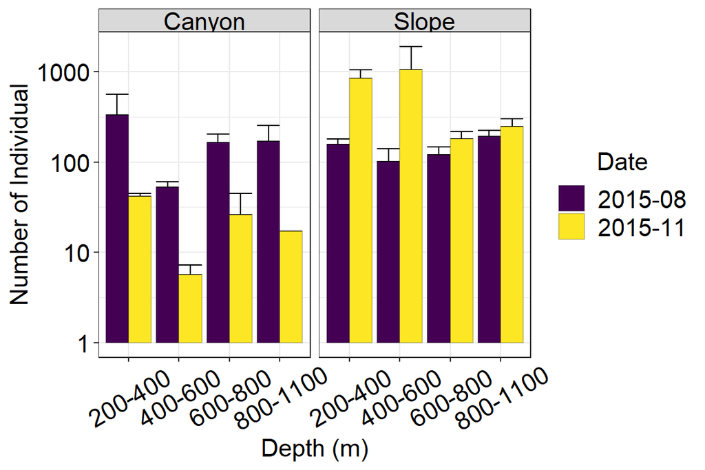

```r
ggplot()+
  geom_errorbar(data=abu, aes(x=Zone, y=Abund, ymin=Abund, ymax=Abund+sd, fill=Date), position="dodge")+
  geom_bar(data=abu, aes(x=Zone, y=Abund, fill=Date), stat="identity", position="dodge", colour=gray(0, 0.2))+
  facet_wrap(~Habitat)+
  labs(x="Depth (m)", y="Number of Individual")+
  scale_fill_viridis(discrete = TRUE)+
  scale_color_viridis(discrete = TRUE)+
  scale_y_log10()+
  theme_bw() %+replace% large %+replace% theme(axis.text.x=element_text(angle=30))
```

# Estimate Hill Numbers

- Bootstrap confidence interval (1000 iterations)

```r
q0 <- iNEXT(t(b), q = 0, size=1:200, nboot=1000)
q1 <- iNEXT(t(b), q = 1, size=1:200, nboot=1000)
q2 <- iNEXT(t(b), q = 2, size=1:200, nboot=1000)
save(list=c("q0", "q1", "q2"), file="../rda/HillNumbers.rda")
```

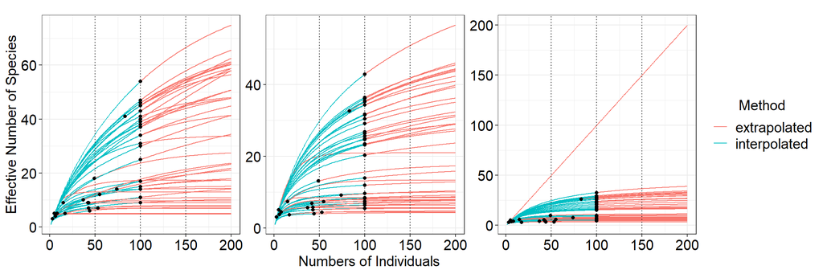

```r
load("../rda/HillNumbers.rda")

h <- rbind(ldply(q0$iNextEst, .id="Sample"),
           ldply(q1$iNextEst, .id="Sample"),
           ldply(q2$iNextEst, .id="Sample"))

ggplot()+
  geom_line(data= subset(h, method!="observed"),
            aes(x=m, y=qD, colour=method, group=Sample))+
  geom_point(data= subset(h, method=="observed"),
             aes(x=m, y=qD, group=Sample))+
  geom_vline(xintercept = c(50, 100, 150), linetype=3)+
  facet_wrap(~order, scale="free")+
  labs(x = "Numbers of Individuals", y = "Effective Number of Species",
       colour="Method")+
  theme_bw()%+replace% large %+replace% no_strip
```

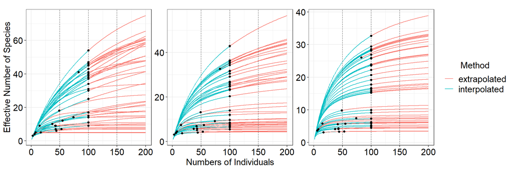

```r
h <- subset(h, !(order==2 & Sample == "OR1_1126_GC2_1_9_2" | Sample == "OR1_1126_GC2_1_9_3"))

ggplot()+
  geom_line(data= subset(h, method!="observed"),
            aes(x=m, y=qD, colour=method, group=Sample))+
  geom_point(data= subset(h, method=="observed"),
             aes(x=m, y=qD, group=Sample))+
  geom_vline(xintercept = c(50, 100, 150), linetype=3)+
  facet_wrap(~order, scale="free")+
  labs(x = "Numbers of Individuals", y = "Effective Number of Species",
       colour="Method")+
  theme_bw()%+replace% large %+replace% no_strip
```

Fig. X. Size-based diversity accumulation curves based on species richness (left), exponential Shannon (middle) and inversed Simpson indices (right). The blue lines indicate the interpolated (rarefied) and red lines indicate extrapolated parts of the accumulation curves based on 1000 permutations. Dotted symbols indicate the observed diversity values. The Hill numbers of order q = 2 (inversed Simpson) for sample “OR1_1126_GC2_1_9_2” and “OR1_1126_GC2_1_9_3” can not be properly estimated and thus were eliminated.

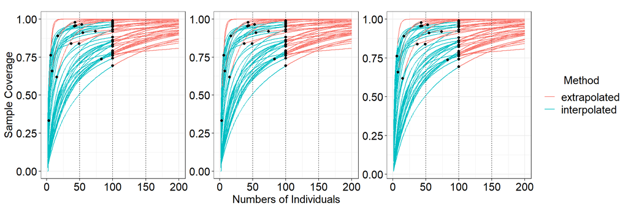

```r
ggplot()+
  geom_line(data= subset(h, method!="observed"),
            aes(x=m, y=SC, colour=method, group=Sample))+
  geom_point(data= subset(h, method=="observed"),
             aes(x=m, y=SC, group=Sample))+
  geom_vline(xintercept = c(50, 100, 150), linetype=3)+
  facet_wrap(~order, scale="free")+
  labs(x = "Numbers of Individuals", y = "Sample Coverage",
       colour="Method")+
  theme_bw()%+replace% large %+replace% no_strip
```

Fig. X. Sample coverage based on species richness (left), exponential Shannon (middle) and inversed Simpson indices (right). The blue lines indicate the interpolated (rarefied) and red lines indicate extrapolated parts of the accumulation curves based on 1000 permutations. Dotted symbols indicate the observed diversity values. The Hill numbers of order q = 2 (inversed Simpson) for sample “OR1_1126_GC2_1_9_2” and “OR1_1126_GC2_1_9_3” can not be properly estimated and thus were eliminated.

```r
# Minimum sample coverage for each order q
min(ldply(lapply(splitBy(~order+Sample, subset(h, order==0)), FUN=function(x)x[dim(x)[1],]))$SC)
```

```
## [1] 0.807
```

```r
min(ldply(lapply(splitBy(~order+Sample, subset(h, order==1)), FUN=function(x)x[dim(x)[1],]))$SC)
```

```
## [1] 0.807
```

```r
min(ldply(lapply(splitBy(~order+Sample, subset(h, order==2)), FUN=function(x)x[dim(x)[1],]))$SC)
```

```
## [1] 0.807
```

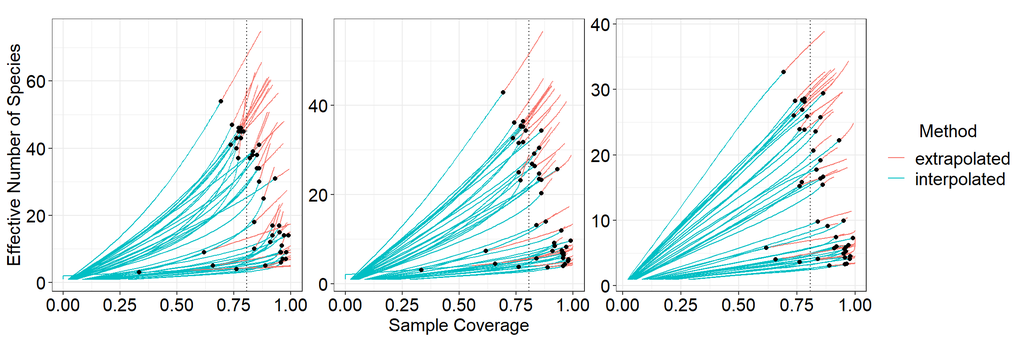

```r
# SC = 0.807

ggplot()+
  geom_line(data= subset(h, method!="observed"),
            aes(x=SC, y=qD, colour=method, group=Sample))+
  geom_point(data= subset(h, method=="observed"),
             aes(x=SC, y=qD, group=Sample))+
  geom_vline(xintercept = c(0.807), linetype=3)+
  facet_wrap(~order, scale="free")+
  labs(x = "Sample Coverage", y = "Effective Number of Species",
       colour="Method")+
  theme_bw()%+replace% large %+replace% no_strip
```

Fig. X. Coverage-based Diversity accumulation curves based on species richness (left), exponential Shannon (middle) and inversed Simpson indices (right) from surface. The blue lines indicate the interpolated (rarefied) and red lines indicate extrapolated parts of the accumulation curves based on 1000 permutations. Dotted symbols indicate the observed diversity values. The vertical dashed line (80.7%) shows the sample with the lowest sample coverage. The Hill numbers of order q = 2 (inversed Simpson) for sample “OR1_1126_GC2_1_9_2” and “OR1_1126_GC2_1_9_3” can not be properly estimated and thus were eliminated.

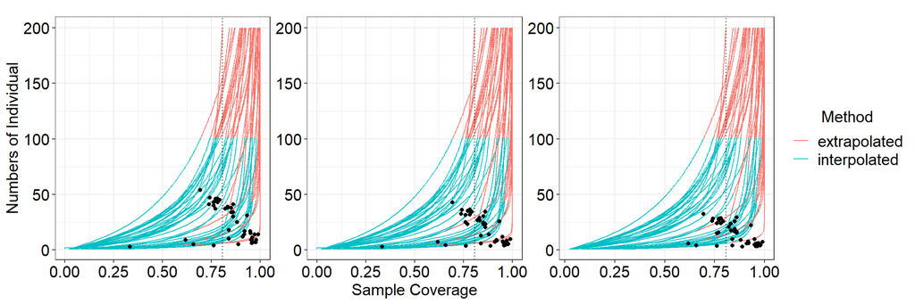

```r
ggplot()+
  geom_line(data= subset(h, method!="observed"),
            aes(x=SC, y=m, colour=method, group=Sample))+
  geom_point(data= subset(h, method=="observed"),
             aes(x=SC, y=qD, group=Sample))+
  geom_vline(xintercept = c(0.807), linetype=3)+
  facet_wrap(~order, scale="free")+
  labs(x = "Sample Coverage", y = "Numbers of Individual",
       colour="Method")+
  theme_bw()%+replace% large %+replace% no_strip
```

Fig. X. Sample size as a function of sample coverage based on species richness (left), exponential Shannon (middle) and inversed Simpson indices (right) from surface. The blue lines indicate the interpolated (rarefied) and red lines indicate extrapolated parts of the accumulation curves based on 1000 permutations. Dotted symbols indicate the observed diversity values. The vertical dashed line (80.7%) shows the sample with the lowest sample coverage. The Hill numbers of order q = 2 (inversed Simpson) for sample “OR1_1126_GC2_1_9_2” and “OR1_1126_GC2_1_9_3” can not be properly estimated and thus were eliminated.

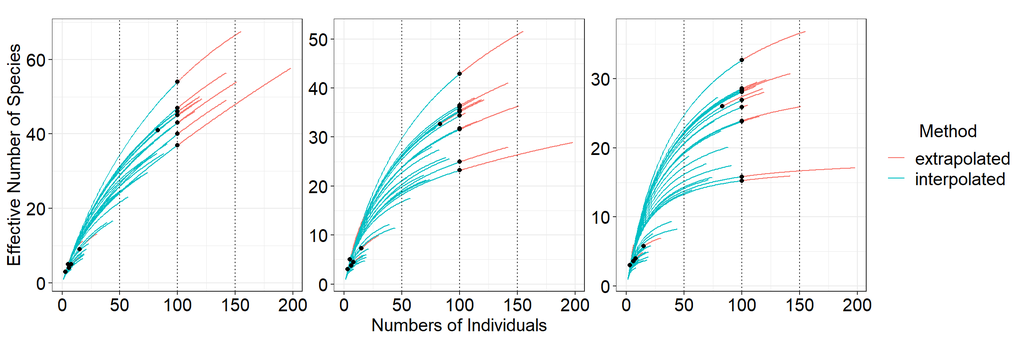

```r
# ~80.7% sample coverage
h0 <- lapply(q0$iNextEst, FUN=function(x) {
  d<-abs(x$SC-0.807)
  x[1:which(d==min(d)),]
  }) %>% ldply(.id="Sample")

h1 <- lapply(q1$iNextEst, FUN=function(x) {
  d<-abs(x$SC-0.807)
  x[1:which(d==min(d)),]
  }) %>% ldply(.id="Sample")

h2 <- lapply(q2$iNextEst, FUN=function(x) {
  d<-abs(x$SC-0.807)
  x[1:which(d==min(d)),]
  }) %>% ldply(.id="Sample")

h <- rbind(h0, h1, h2)
h <- subset(h, !(order==2 & Sample == "OR1_1126_GC2_1_9_3"))

ggplot()+
  geom_line(data= subset(h, method!="observed"),
            aes(x=m, y=qD, colour=method, group=Sample))+
  geom_point(data= subset(h, method=="observed"),
             aes(x=m, y=qD, group=Sample))+
  geom_vline(xintercept = c(50, 100, 150), linetype=3)+
  facet_wrap(~order, scale="free")+
  labs(x = "Numbers of Individuals", y = "Effective Number of Species",
       colour="Method")+
  theme_bw()%+replace% large %+replace% no_strip
```

Fig. X. Size-based diversity accumulation curves based on species richness (left), exponential Shannon (middle) and inversed Simpson indices (right). The blue lines indicate the interpolated (rarefied) and red lines indicate extrapolated parts of the accumulation curves based on 1000 permutations. Dotted symbols indicate the observed diversity values. Sample size (numbers of individuals) and the Hill numbers are cut off by 80.7% sample coverage. The Hill numbers of order q = 2 (inversed Simpson) for sample “OR1_1126_GC2_1_9_3” can not be properly estimated and thus were eliminated.

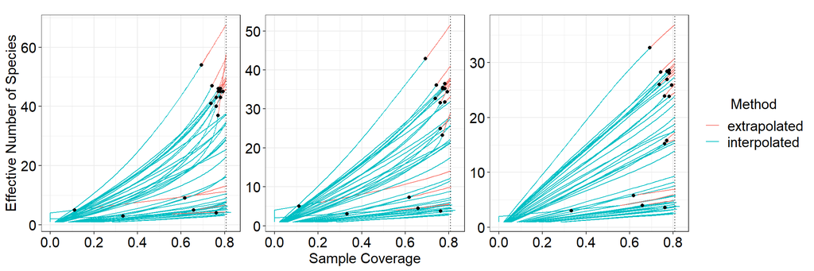

```r
ggplot()+
  geom_line(data= subset(h, method!="observed"),
            aes(x=SC, y=qD, colour=method, group=Sample))+
  geom_point(data= subset(h, method=="observed"),
             aes(x=SC, y=qD, group=Sample))+
  geom_vline(xintercept = c(0.807), linetype=3)+
  facet_wrap(~order, scale="free")+
  labs(x = "Sample Coverage", y = "Effective Number of Species",
       colour="Method")+
  theme_bw()%+replace% large %+replace% no_strip
```

Fig. X. Coverage-based Diversity accumulation curves based on species richness (left), exponential Shannon (middle) and inversed Simpson indices (right) from surface. The blue lines indicate the interpolated (rarefied) and red lines indicate extrapolated parts of the accumulation curves based on 1000 permutations. Dotted symbols indicate the observed diversity values. Sample size (numbers of individuals) and the Hill numbers are cut off by 80.7% sample coverage. The Hill numbers of order q = 2 (inversed Simpson) for sample “OR1_1126_GC2_1_9_3” can not be properly estimated and thus were eliminated.

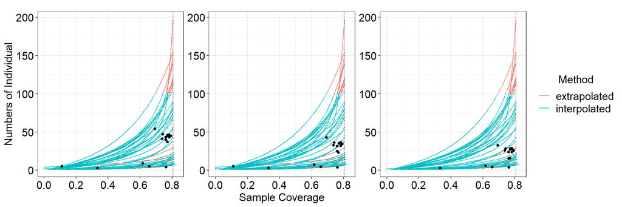

```r
ggplot()+
  geom_line(data= subset(h, method!="observed"),
            aes(x=SC, y=m, colour=method, group=Sample))+
  geom_point(data= subset(h, method=="observed"),
             aes(x=SC, y=qD, group=Sample))+
  geom_vline(xintercept = c(0.807), linetype=3)+
  facet_wrap(~order, scale="free")+
  labs(x = "Sample Coverage", y = "Numbers of Individual",
       colour="Method")+
  theme_bw()%+replace% large %+replace% no_strip
```

Fig. X. Sample size as a function of sample coverage based on species richness (left), exponential Shannon (middle) and inversed Simpson indices (right) from surface. The blue lines indicate the interpolated (rarefied) and red lines indicate extrapolated parts of the accumulation curves based on 1000 permutations. Dotted symbols indicate the observed diversity values. Sample size (numbers of individuals) and the Hill numbers are cut off by 80.7% sample coverage. The Hill numbers of order q = 2 (inversed Simpson) for sample “OR1_1126_GC2_1_9_3” can not be properly estimated and thus were eliminated.

```r
# ~80.7% sample coverage
h0 <- lapply(q0$iNextEst, FUN=function(x) {
  d<-abs(x$SC-0.807)
  o <- subset(x, d==min(d))
  o[dim(o)[1],]
  }) %>% ldply(.id="Sample")
round(mean(h0$SC), 3)
```

```
## [1] 0.808
```

```r
h1 <- lapply(q1$iNextEst, FUN=function(x) {
  d<-abs(x$SC-0.807)
  o <- subset(x, d==min(d))
  o[dim(o)[1],]
  }) %>% ldply(.id="Sample")
round(mean(h1$SC), 3)
```

```
## [1] 0.808
```

```r
h2 <- lapply(q2$iNextEst, FUN=function(x) {
  d<-abs(x$SC-0.807)
  o <- subset(x, d==min(d))
  o[dim(o)[1],]
  }) %>% ldply(.id="Sample")
# Set the bad diversity estimates to NA
h2[h2$Sample == "OR1_1126_GC2_1_9_3", c("qD", "qD.LCL", "qD.UCL", "SC", "SC.LCL", "SC.UCL")] <- NA
round(mean(h2$SC, na.rm=TRUE), 3)
```

```
## [1] 0.808
```

```r
# 100 randomly selected individual
#h0 <- subset(ldply(q0$iNextEst, .id="Sample"), m==100)
#h1 <- subset(ldply(q1$iNextEst, .id="Sample"), m==100)
#h2 <- subset(ldply(q2$iNextEst, .id="Sample"), m==100)
# Set the bad diversity estimates to NA
#h2[h2$Sample == "OR1_1126_GC2_1_9_2"|h2$Sample == "OR1_1126_GC2_1_9_3", c("qD", "qD.LCL", "qD.UCL", "SC", "SC.LCL", "SC.UCL")] <- NA
```

## Observed number of species

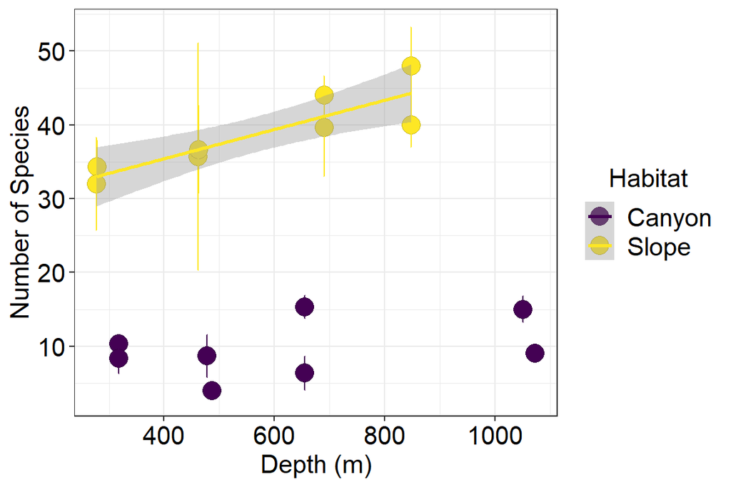

```r
fr <- strsplit(as.character(q0$DataInfo$site), split="_") %>% ldply
fr <- cbind(paste(fr$V1, fr$V2, sep="_"), fr[,-1:-2])
names(fr) <- c("Cruise", "Station", "Deployment", "Tube", "Subcore")

div <- cbind(S.obs=q0$DataInfo$S.obs, d0=h0$qD, d1 = h1$qD, d2=h2$qD)
#row.names(div) <- NULL
div <- cbind(fr, div)
div <- summaryBy(S.obs+d0+d1+d2~Cruise+Station+Deployment, div, FUN=c(mean, sd, length))
names(div)[-1:-3] <- c("S.obs", "d0", "d1", "d2", "S.obs.sd", "d0.sd", "d1.sd", "d2.sd", "S.obs.n", "d0.n", "d1.n", "d2.n")

id1 <- with(div, paste(Cruise, Station, Deployment))
id2 <- with(nema_cruise, paste(Cruise, Station, Deployment))
div <- cbind(div, nema_cruise[match(id1, id2), -3:-5])

ggplot(data=div,
       aes(x=Depth, y=S.obs, ymin=S.obs-S.obs.sd, ymax=S.obs+S.obs.sd, colour=Habitat))+
  geom_point(aes(fill=Habitat), pch=21, colour=gray(0, 0.2), size=5)+
  geom_errorbar()+
  stat_smooth(data=subset(div, Habitat=="Slope"),
       aes(x=Depth, y=S.obs, colour=Habitat), method="lm", fill="gray60")+
  labs(x="Depth (m)", y="Number of Species")+
  scale_fill_viridis(discrete = TRUE)+
  scale_color_viridis(discrete = TRUE)+
  theme_bw() %+replace% large
```

```r
# Linear regression
hl <- splitBy(~Habitat, div)
lapply(hl, FUN=function(x)summary(lm(S.obs~Depth, data=x)))
```

```
## $Canyon
##
## Call:
## lm(formula = S.obs ~ Depth, data = x)
##
## Residuals:
##     Min      1Q  Median      3Q     Max
## -4.8867 -3.0501  0.0747  2.5394  5.5755
##
## Coefficients:
##             Estimate Std. Error t value Pr(>|t|)
## (Intercept) 6.361518   3.419092   1.861    0.112
## Depth       0.005185   0.004973   1.043    0.337
##
## Residual standard error: 3.893 on 6 degrees of freedom
## Multiple R-squared:  0.1534, Adjusted R-squared:  0.01231
## F-statistic: 1.087 on 1 and 6 DF,  p-value: 0.3373
##
##
## $Slope
##
## Call:
## lm(formula = S.obs ~ Depth, data = x)
##
## Residuals:
##     Min      1Q  Median      3Q     Max
## -4.3133 -1.1208 -0.4987  1.6849  3.6867
##
## Coefficients:
##              Estimate Std. Error t value Pr(>|t|)
## (Intercept) 27.493078   2.751996   9.990 5.82e-05 ***
## Depth        0.019835   0.004515   4.394   0.0046 **
## ---
## Signif. codes:  0 '***' 0.001 '**' 0.01 '*' 0.05 '.' 0.1 ' ' 1
##
## Residual standard error: 2.772 on 6 degrees of freedom
## Multiple R-squared:  0.7629, Adjusted R-squared:  0.7234
## F-statistic:  19.3 on 1 and 6 DF,  p-value: 0.0046
```

```r
# Linear Mixed-Effects Models
f <- lme(fixed = S.obs ~ Habitat*Depth, random = ~1|Cruise, data=div, method = "REML", weights=varIdent(form=~1|Cruise))
summary(f)
```

```
## Linear mixed-effects model fit by REML
##  Data: div
##        AIC      BIC    logLik
##   101.0525 104.4469 -43.52627
##
## Random effects:
##  Formula: ~1 | Cruise
##         (Intercept) Residual
## StdDev:    3.027131 2.453253
##
## Variance function:
##  Structure: Different standard deviations per stratum
##  Formula: ~1 | Cruise
##  Parameter estimates:
##  OR1_1114  OR1_1126
## 1.0000000 0.8752995
## Fixed effects: S.obs ~ Habitat * Depth
##                        Value Std.Error DF  t-value p-value
## (Intercept)         6.422244 2.9335052 11 2.189273  0.0510
## HabitatSlope       21.558820 3.0274919 11 7.121017  0.0000
## Depth               0.004950 0.0029136 11 1.698860  0.1174
## HabitatSlope:Depth  0.014113 0.0047259 11 2.986190  0.0124
##  Correlation:
##                    (Intr) HbttSl Depth
## HabitatSlope       -0.453
## Depth              -0.625  0.606
## HabitatSlope:Depth  0.386 -0.925 -0.617
##
## Standardized Within-Group Residuals:
##        Min         Q1        Med         Q3        Max
## -1.2995360 -0.6645470  0.1946463  0.5821909  1.4682874
##
## Number of Observations: 16
## Number of Groups: 2
```

```r
# Normalized enivronmental data to mean zero and unit variance
es <- as.data.frame(scale(div[, c(-1:-23, -45)]))

# General linear Models
dat <- cbind(div[, c(1:23, 45)], es)
f <- gls(S.obs ~ Speed+CN+Salinity+over20+TOC+transmissometer+Temperature, data=dat)
summary(f)
```

```
## Generalized least squares fit by REML
##   Model: S.obs ~ Speed + CN + Salinity + over20 + TOC + transmissometer +      Temperature
##   Data: dat
##        AIC      BIC    logLik
##   83.28878 84.00376 -32.64439
##
## Coefficients:
##                     Value Std.Error   t-value p-value
## (Intercept)     24.208333  1.251815 19.338591  0.0000
## Speed           -3.717289  3.538928 -1.050400  0.3242
## CN               3.079616  2.025142  1.520691  0.1668
## Salinity        -1.448832  1.498685 -0.966735  0.3620
## over20           3.942649  2.832092  1.392133  0.2014
## TOC              8.802106  3.434023  2.563205  0.0335
## transmissometer  6.729000  2.560597  2.627902  0.0303
## Temperature      3.762024  1.498929  2.509808  0.0364
##
##  Correlation:
##                 (Intr) Speed  CN     Salnty over20 TOC    trnsms
## Speed            0.000
## CN               0.000 -0.451
## Salinity         0.000 -0.396  0.026
## over20           0.000 -0.442  0.266  0.318
## TOC              0.000  0.533 -0.703  0.012  0.036
## transmissometer  0.000  0.212  0.378 -0.159  0.288 -0.324
## Temperature      0.000 -0.035 -0.118 -0.109 -0.298  0.103 -0.296
##
## Standardized residuals:
##        Min         Q1        Med         Q3        Max
## -1.3002762 -0.3893298 -0.1961969  0.4299275  1.6123160
##
## Residual standard error: 5.007259
## Degrees of freedom: 16 total; 8 residual
```

```r
# Model selection
ms <- dredge(f)
kable(ms[1:10,])
```

|  | (Intercept) | CN | over20 | Salinity | Speed | Temperature | TOC | transmissometer | df | logLik | AICc | delta | weight |
| --- | --- | --- | --- | --- | --- | --- | --- | --- | --- | --- | --- | --- | --- |
| 113 | 24.20833 | NA | NA | NA | NA | 4.216725 | 12.12952 | 4.559750 | 5 | -42.16941 | 100.3388 | 0.0000000 | 0.19324692 |
| 115 | 24.20833 | NA | 3.017912 | NA | NA | 3.647730 | 13.48186 | 5.763590 | 6 | -39.62554 | 100.5844 | 0.2456061 | 0.17091489 |
| 117 | 24.20833 | NA | NA | -2.015811 | NA | 4.447022 | 11.69344 | 4.783019 | 6 | -39.86407 | 101.0615 | 0.7226485 | 0.13464538 |
| 121 | 24.20833 | NA | NA | NA | -1.535019 | 4.417978 | 11.43601 | 3.862356 | 6 | -40.02829 | 101.3899 | 1.0510881 | 0.11425408 |
| 114 | 24.20833 | 1.33545 | NA | NA | NA | 4.058774 | 10.78467 | 5.481200 | 6 | -40.36103 | 102.0554 | 1.7165751 | 0.08191493 |
| 57 | 24.20833 | NA | NA | NA | -4.179696 | 5.018420 | 12.21642 | NA | 5 | -43.03906 | 102.0781 | 1.7392969 | 0.08098956 |
| 123 | 24.20833 | NA | 3.683155 | NA | -2.656831 | 3.870636 | 12.57963 | 4.821895 | 7 | -37.21460 | 102.4292 | 2.0903937 | 0.06794998 |
| 99 | 24.20833 | NA | 5.007039 | NA | NA | NA | 12.87976 | 7.116377 | 5 | -43.43141 | 102.8628 | 2.5240011 | 0.05470572 |
| 59 | 24.20833 | NA | 2.138806 | NA | -5.212667 | 4.787202 | 12.99310 | NA | 6 | -40.78076 | 102.8949 | 2.5560405 | 0.05383633 |
| 119 | 24.20833 | NA | 2.379996 | -1.771163 | NA | 3.970349 | 12.81285 | 5.705298 | 7 | -37.57176 | 103.1435 | 2.8047016 | 0.04754221 |

```r
# Model averaging
ma <- model.avg(ms, fit=TRUE)
kable(summary(ma)$coefmat.full)
```

|  | Estimate | Std. Error | Adjusted SE | z value | Pr(>\|z\|) |
| --- | --- | --- | --- | --- | --- |
| (Intercept) | 24.2083333 | 1.453335 | 1.630425 | 14.8478632 | 0.0000000 |
| Temperature | 3.4225605 | 2.267046 | 2.378835 | 1.4387549 | 0.1502200 |
| TOC | 11.5994722 | 3.889382 | 4.127685 | 2.8101638 | 0.0049516 |
| transmissometer | 4.3610824 | 3.457525 | 3.625125 | 1.2030158 | 0.2289702 |
| over20 | 1.4109169 | 2.721876 | 2.888996 | 0.4883762 | 0.6252834 |
| Salinity | -0.4884575 | 1.168275 | 1.244343 | 0.3925425 | 0.6946574 |
| Speed | -1.3263665 | 3.039898 | 3.225864 | 0.4111663 | 0.6809506 |
| CN | 0.6249945 | 1.796200 | 1.890503 | 0.3305970 | 0.7409489 |

```r
# Best model
b <- get.models(ms, subset=1)[[1]]
kable(summary(b)$tTable)
```

|  | Value | Std.Error | t-value | p-value |
| --- | --- | --- | --- | --- |
| (Intercept) | 24.208333 | 1.336118 | 18.118407 | 0.0000000 |
| Temperature | 4.216725 | 1.476597 | 2.855705 | 0.0144687 |
| TOC | 12.129516 | 2.073277 | 5.850409 | 0.0000783 |
| transmissometer | 4.559750 | 1.976900 | 2.306516 | 0.0397261 |

```r
# Relative importance
kable(summary(ma)$sw)
```

|  | x |
| --- | --- |
| TOC | 0.9634640 |
| Temperature | 0.7972715 |
| transmissometer | 0.7642366 |
| over20 | 0.4149971 |
| Speed | 0.3984150 |
| CN | 0.2897839 |
| Salinity | 0.2727747 |

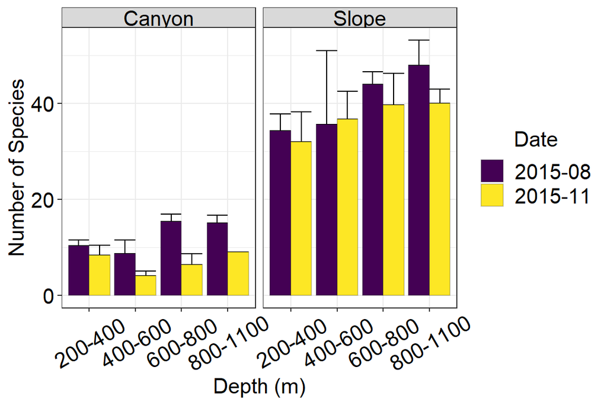

```r
ggplot()+
  geom_errorbar(data=div, aes(x=Zone, y=S.obs, ymin=S.obs, ymax=S.obs+S.obs.sd, fill=Date), position="dodge")+
  geom_bar(data=div, aes(x=Zone, y=S.obs, fill=Date), stat="identity", position="dodge", colour=gray(0, 0.2))+
  facet_wrap(~Habitat)+
  labs(x="Depth (m)", y="Number of Species")+
  scale_fill_viridis(discrete = TRUE)+
  scale_color_viridis(discrete = TRUE)+
  theme_bw() %+replace% large %+replace% theme(axis.text.x=element_text(angle=30))
```

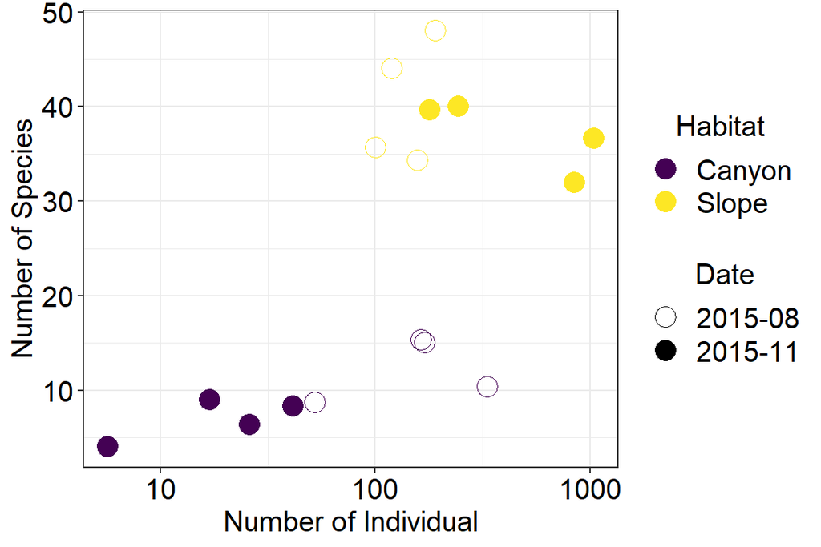

```r
div$Abund <- abu$Abund
ggplot(data=div, aes(x=Abund, y=S.obs, colour=Habitat, shape=Date))+
  geom_point(size=5)+
  labs(x="Number of Individual", y="Number of Species")+
  scale_shape_manual(values=c(1, 19))+
  scale_x_log10()+
  scale_color_viridis(discrete = TRUE)+
  theme_bw() %+replace% large
```

## q=0 or species richness

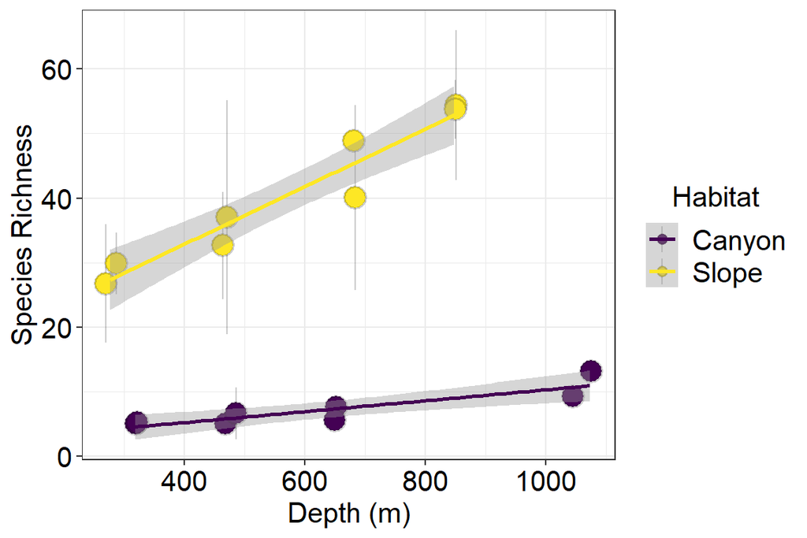

```r
ggplot(data=div,
       aes(x=Depth, y=d0, ymin=d0-d0.sd, ymax=d0+d0.sd, colour=Habitat))+
  geom_pointrange(aes(fill=Habitat), pch=21, colour=gray(0, 0.2), fatten = 10,
                  position=position_jitter(width=10))+
  stat_smooth(method="lm", fill="gray60")+
  labs(x="Depth (m)", y="Species Richness")+
  scale_fill_viridis(discrete = TRUE)+
  scale_color_viridis(discrete = TRUE)+
  theme_bw() %+replace% large
```

```r
# Linear regression
hl <- splitBy(~Habitat, div)
lapply(hl, FUN=function(x)summary(lm(d0~Depth, data=x)))
```

```
## $Canyon
##
## Call:
## lm(formula = d0 ~ Depth, data = x)
##
## Residuals:
##     Min      1Q  Median      3Q     Max
## -1.8264 -1.0433  0.3256  0.6468  2.2704
##
## Coefficients:
##             Estimate Std. Error t value Pr(>|t|)
## (Intercept) 1.897619   1.280434   1.482  0.18885
## Depth       0.008435   0.001862   4.529  0.00398 **
## ---
## Signif. codes:  0 '***' 0.001 '**' 0.01 '*' 0.05 '.' 0.1 ' ' 1
##
## Residual standard error: 1.458 on 6 degrees of freedom
## Multiple R-squared:  0.7737, Adjusted R-squared:  0.736
## F-statistic: 20.52 on 1 and 6 DF,  p-value: 0.003977
##
##
## $Slope
##
## Call:
## lm(formula = d0 ~ Depth, data = x)
##
## Residuals:
##    Min     1Q Median     3Q    Max
## -5.700 -1.224  1.172  1.754  3.034
##
## Coefficients:
##              Estimate Std. Error t value Pr(>|t|)
## (Intercept) 15.049996   3.197072   4.707 0.003301 **
## Depth        0.044530   0.005245   8.491 0.000146 ***
## ---
## Signif. codes:  0 '***' 0.001 '**' 0.01 '*' 0.05 '.' 0.1 ' ' 1
##
## Residual standard error: 3.22 on 6 degrees of freedom
## Multiple R-squared:  0.9232, Adjusted R-squared:  0.9104
## F-statistic: 72.09 on 1 and 6 DF,  p-value: 0.000146
```

```r
# Linear Mixed-Effects Models
f <- lme(fixed = d0 ~ Habitat*Depth, random = ~1|Cruise, data=div, method = "REML", weights=varIdent(form=~1|Cruise))
summary(f)
```

```
## Linear mixed-effects model fit by REML
##  Data: div
##        AIC     BIC    logLik
##   95.12905 98.5234 -40.56453
##
## Random effects:
##  Formula: ~1 | Cruise
##         (Intercept)  Residual
## StdDev:   0.7502995 0.8519262
##
## Variance function:
##  Structure: Different standard deviations per stratum
##  Formula: ~1 | Cruise
##  Parameter estimates:
## OR1_1114 OR1_1126
## 1.000000 4.116406
## Fixed effects: d0 ~ Habitat * Depth
##                        Value Std.Error DF   t-value p-value
## (Intercept)         2.432110 1.2180920 11  1.996655  0.0712
## HabitatSlope       14.378457 1.5565959 11  9.237116  0.0000
## Depth               0.006473 0.0015136 11  4.276727  0.0013
## HabitatSlope:Depth  0.037726 0.0024361 11 15.486255  0.0000
##  Correlation:
##                    (Intr) HbttSl Depth
## HabitatSlope       -0.564
## Depth              -0.779  0.609
## HabitatSlope:Depth  0.484 -0.926 -0.621
##
## Standardized Within-Group Residuals:
##        Min         Q1        Med         Q3        Max
## -1.9654755 -0.5668793 -0.1394362  0.4205499  1.3642021
##
## Number of Observations: 16
## Number of Groups: 2
```

```r
# General linear Models
dat <- cbind(div[, c(1:23, 45:46)], es)
f <- gls(d0 ~ Speed+CN+Salinity+over20+TOC+transmissometer+Temperature, data=dat)
summary(f)
```

```
## Generalized least squares fit by REML
##   Model: d0 ~ Speed + CN + Salinity + over20 + TOC + transmissometer +      Temperature
##   Data: dat
##        AIC      BIC    logLik
##   88.18052 88.89549 -35.09026
##
## Coefficients:
##                     Value Std.Error   t-value p-value
## (Intercept)     23.811083  1.699489 14.010729  0.0000
## Speed            0.256441  4.804520  0.053375  0.9587
## CN               0.409696  2.749375  0.149014  0.8852
## Salinity        -1.749131  2.034646 -0.859674  0.4150
## over20           5.977026  3.844906  1.554531  0.1587
## TOC             14.983141  4.662100  3.213818  0.0124
## transmissometer  9.429508  3.476319  2.712498  0.0266
## Temperature      0.838507  2.034976  0.412048  0.6911
##
##  Correlation:
##                 (Intr) Speed  CN     Salnty over20 TOC    trnsms
## Speed            0.000
## CN               0.000 -0.451
## Salinity         0.000 -0.396  0.026
## over20           0.000 -0.442  0.266  0.318
## TOC              0.000  0.533 -0.703  0.012  0.036
## transmissometer  0.000  0.212  0.378 -0.159  0.288 -0.324
## Temperature      0.000 -0.035 -0.118 -0.109 -0.298  0.103 -0.296
##
## Standardized residuals:
##        Min         Q1        Med         Q3        Max
## -1.3449936 -0.5102668  0.1197368  0.6670029  0.9405259
##
## Residual standard error: 6.797957
## Degrees of freedom: 16 total; 8 residual
```

```r
# Model selection
ms <- dredge(f)
kable(ms[1:10,])
```

|  | (Intercept) | CN | over20 | Salinity | Speed | Temperature | TOC | transmissometer | df | logLik | AICc | delta | weight |
| --- | --- | --- | --- | --- | --- | --- | --- | --- | --- | --- | --- | --- | --- |
| 99 | 23.81108 | NA | 6.931315 | NA | NA | NA | 15.83907 | 9.309679 | 5 | -42.75189 | 101.5038 | 0.000000 | 0.30238629 |
| 107 | 23.81108 | NA | 7.168435 | NA | -0.8007028 | NA | 15.55607 | 9.050789 | 6 | -40.59219 | 102.5177 | 1.013915 | 0.18213492 |
| 103 | 23.81108 | NA | 6.539584 | -1.501806 | NA | NA | 15.22665 | 9.361702 | 6 | -40.92467 | 103.1827 | 1.678893 | 0.13061562 |
| 100 | 23.81108 | 0.1859984 | 6.947268 | NA | NA | NA | 15.67032 | 9.440106 | 6 | -41.09199 | 103.5173 | 2.013522 | 0.11049213 |
| 115 | 23.81108 | NA | 6.602599 | NA | NA | 0.6028105 | 15.93857 | 9.086122 | 6 | -41.21752 | 103.7684 | 2.264584 | 0.09745721 |
| 111 | 23.81108 | NA | 6.271456 | -1.663113 | 0.7633273 | NA | 15.43066 | 9.614095 | 7 | -38.65646 | 105.3129 | 3.809122 | 0.04502168 |
| 108 | 23.81108 | 0.5729218 | 7.352925 | NA | -1.2577530 | NA | 14.87475 | 9.304760 | 7 | -38.72738 | 105.4548 | 3.950978 | 0.04193901 |
| 123 | 23.81108 | NA | 6.856693 | NA | -1.0147939 | 0.6879508 | 15.59396 | 8.726435 | 7 | -38.99235 | 105.9847 | 4.480911 | 0.03217694 |
| 105 | 23.81108 | NA | NA | NA | 1.8957498 | NA | 13.10666 | 7.586939 | 5 | -45.05021 | 106.1004 | 4.596635 | 0.03036795 |
| 109 | 23.81108 | NA | NA | -2.754858 | 3.9275903 | NA | 13.40662 | 8.823438 | 6 | -42.48609 | 106.3055 | 4.801723 | 0.02740824 |

```r
# Model averaging
ma <- model.avg(ms, fit=TRUE)
kable(summary(ma)$coefmat.full)
```

|  | Estimate | Std. Error | Adjusted SE | z value | Pr(>\|z\|) |
| --- | --- | --- | --- | --- | --- |
| (Intercept) | 23.8110833 | 1.602674 | 1.796915 | 13.2510889 | 0.0000000 |
| over20 | 5.3403977 | 3.862206 | 4.097446 | 1.3033478 | 0.1924561 |
| TOC | 15.1312150 | 3.583217 | 3.919393 | 3.8606016 | 0.0001131 |
| transmissometer | 8.4372472 | 3.428524 | 3.683902 | 2.2903017 | 0.0220038 |
| Speed | -0.0672683 | 2.588999 | 2.845175 | 0.0236429 | 0.9811374 |
| Salinity | -0.4731815 | 1.235211 | 1.325075 | 0.3570980 | 0.7210184 |
| CN | -0.0121840 | 1.351921 | 1.485588 | 0.0082015 | 0.9934563 |
| Temperature | 0.2563924 | 1.078765 | 1.176144 | 0.2179941 | 0.8274337 |

```r
# Best model
b <- get.models(ms, subset=1)[[1]]
kable(summary(b)$tTable)
```

|  | Value | Std.Error | t-value | p-value |
| --- | --- | --- | --- | --- |
| (Intercept) | 23.811083 | 1.466034 | 16.241836 | 0.0000000 |
| over20 | 6.931315 | 2.755371 | 2.515566 | 0.0271292 |
| TOC | 15.839070 | 2.606623 | 6.076471 | 0.0000553 |
| transmissometer | 9.309679 | 2.376799 | 3.916898 | 0.0020466 |

```r
# Relative importance
kable(summary(ma)$sw)
```

|  | x |
| --- | --- |
| TOC | 0.9940583 |
| transmissometer | 0.9473144 |
| over20 | 0.7958682 |
| Speed | 0.3466504 |
| Salinity | 0.2659241 |
| CN | 0.2360960 |
| Temperature | 0.2172008 |

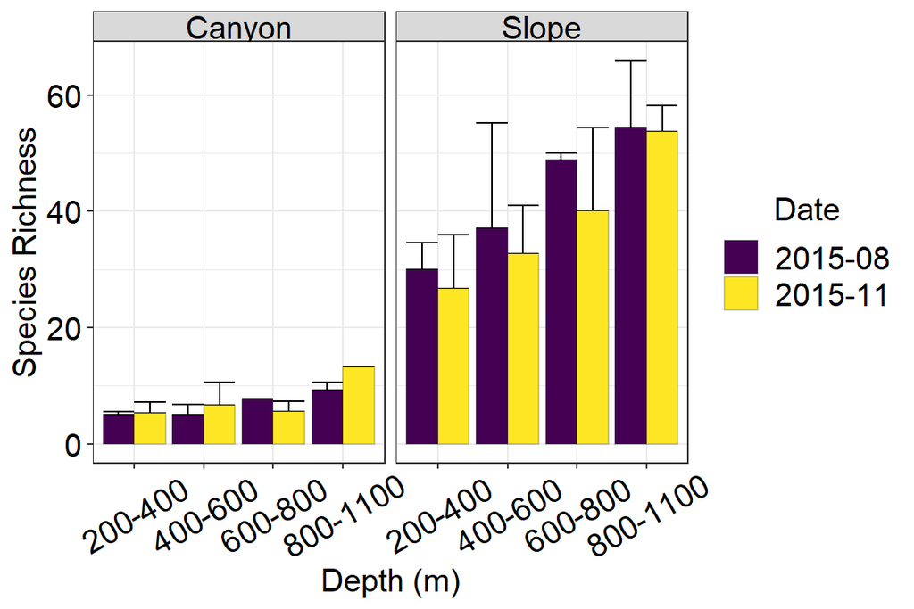

```r
ggplot()+
  geom_errorbar(data=div, aes(x=Zone, y=d0, ymin=d0, ymax=d0+d0.sd, fill=Date), position="dodge")+
  geom_bar(data=div, aes(x=Zone, y=d0, fill=Date), stat="identity", position="dodge", colour=gray(0, 0.2))+
  facet_wrap(~Habitat)+
  labs(x="Depth (m)", y="Species Richness")+
  scale_fill_viridis(discrete = TRUE)+
  scale_color_viridis(discrete = TRUE)+
  theme_bw() %+replace% large %+replace% theme(axis.text.x=element_text(angle=30))
```

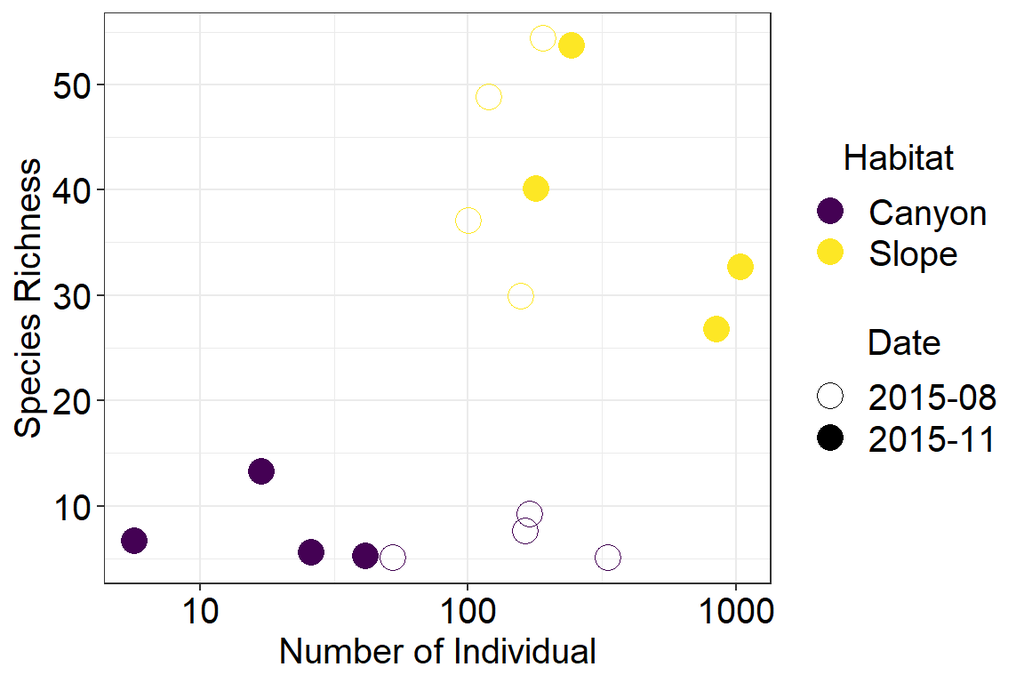

```r
ggplot(data=div, aes(x=Abund, y=d0, colour=Habitat, shape=Date))+
  geom_point(size=5)+
  labs(x="Number of Individual", y="Species Richness")+
  scale_shape_manual(values=c(1, 19))+
  scale_x_log10()+
  scale_color_viridis(discrete = TRUE)+
  theme_bw() %+replace% large
```

## q=1 or exponential Shannon diversity

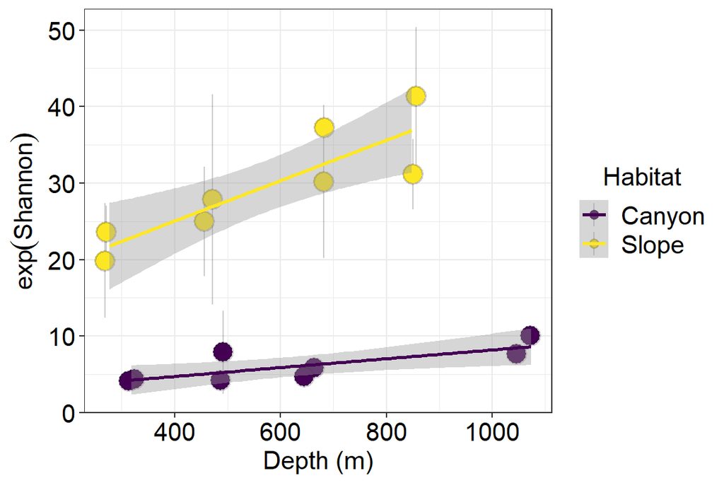

```r
ggplot(data=div,
       aes(x=Depth, y=d1, ymin=d1-d1.sd, ymax=d1+d1.sd, colour=Habitat))+
  geom_pointrange(aes(fill=Habitat), pch=21, colour=gray(0, 0.2), fatten = 10,
                  position=position_jitter(width=10))+
  stat_smooth(method="lm", fill="gray60")+
  labs(x="Depth (m)", y=expression(exp(Shannon)))+
  scale_fill_viridis(discrete = TRUE)+
  scale_color_viridis(discrete = TRUE)+
  theme_bw() %+replace% large
```

```r
# Linear regression
hl <- splitBy(~Habitat, div)
lapply(hl, FUN=function(x)summary(lm(d1~Depth, data=x)))
```

```
## $Canyon
##
## Call:
## lm(formula = d1 ~ Depth, data = x)
##
## Residuals:
##     Min      1Q  Median      3Q     Max
## -1.5041 -0.9339 -0.2977  0.3897  2.6157
##
## Coefficients:
##             Estimate Std. Error t value Pr(>|t|)
## (Intercept) 2.431842   1.291861   1.882   0.1088
## Depth       0.005777   0.001879   3.075   0.0218 *
## ---
## Signif. codes:  0 '***' 0.001 '**' 0.01 '*' 0.05 '.' 0.1 ' ' 1
##
## Residual standard error: 1.471 on 6 degrees of freedom
## Multiple R-squared:  0.6117, Adjusted R-squared:  0.547
## F-statistic: 9.454 on 1 and 6 DF,  p-value: 0.02181
##
##
## $Slope
##
## Call:
## lm(formula = d1 ~ Depth, data = x)
##
## Residuals:
##     Min      1Q  Median      3Q     Max
## -5.7768 -2.0641 -0.2461  2.3949  4.5125
##
## Coefficients:
##              Estimate Std. Error t value Pr(>|t|)
## (Intercept) 14.456608   3.868517   3.737  0.00966 **
## Depth        0.026442   0.006346   4.167  0.00590 **
## ---
## Signif. codes:  0 '***' 0.001 '**' 0.01 '*' 0.05 '.' 0.1 ' ' 1
##
## Residual standard error: 3.897 on 6 degrees of freedom
## Multiple R-squared:  0.7432, Adjusted R-squared:  0.7004
## F-statistic: 17.36 on 1 and 6 DF,  p-value: 0.0059
```

```r
# Linear Mixed-Effects Models
f <- lme(fixed = d1 ~ Habitat*Depth, random = ~1|Cruise, data=div, method = "REML", weights=varIdent(form=~1|Cruise))
summary(f)
```

```
## Linear mixed-effects model fit by REML
##  Data: div
##        AIC      BIC    logLik
##   98.85746 102.2518 -42.42873
##
## Random effects:
##  Formula: ~1 | Cruise
##         (Intercept)  Residual
## StdDev:    1.285402 0.8335872
##
## Variance function:
##  Structure: Different standard deviations per stratum
##  Formula: ~1 | Cruise
##  Parameter estimates:
## OR1_1114 OR1_1126
## 1.000000 5.295347
## Fixed effects: d1 ~ Habitat * Depth
##                        Value Std.Error DF   t-value p-value
## (Intercept)         1.785909 1.4785387 11  1.207888  0.2524
## HabitatSlope       11.507348 1.5403980 11  7.470373  0.0000
## Depth               0.004960 0.0014985 11  3.310061  0.0070
## HabitatSlope:Depth  0.027269 0.0024110 11 11.310264  0.0000
##  Correlation:
##                    (Intr) HbttSl Depth
## HabitatSlope       -0.460
## Depth              -0.635  0.609
## HabitatSlope:Depth  0.395 -0.926 -0.622
##
## Standardized Within-Group Residuals:
##         Min          Q1         Med          Q3         Max
## -2.00184011 -0.63342814  0.07772485  0.43123366  1.19754403
##
## Number of Observations: 16
## Number of Groups: 2
```

```r
# General linear Models
dat <- cbind(div[, c(1:23, 45:46)], es)
f <- gls(d1 ~ Speed+CN+Salinity+over20+TOC+transmissometer+Temperature, data=dat)
summary(f)
```

```
## Generalized least squares fit by REML
##   Model: d1 ~ Speed + CN + Salinity + over20 + TOC + transmissometer +      Temperature
##   Data: dat
##        AIC      BIC    logLik
##   83.59287 84.30785 -32.79644
##
## Coefficients:
##                     Value Std.Error   t-value p-value
## (Intercept)     17.793312  1.275834 13.946416  0.0000
## Speed           -2.521972  3.606831 -0.699221  0.5042
## CN               1.804134  2.064000  0.874096  0.4075
## Salinity        -1.513705  1.527441 -0.991007  0.3507
## over20           4.958517  2.886433  1.717870  0.1241
## TOC              7.006896  3.499914  2.002020  0.0803
## transmissometer  7.665678  2.609729  2.937346  0.0188
## Temperature      0.784527  1.527689  0.513538  0.6215
##
##  Correlation:
##                 (Intr) Speed  CN     Salnty over20 TOC    trnsms
## Speed            0.000
## CN               0.000 -0.451
## Salinity         0.000 -0.396  0.026
## over20           0.000 -0.442  0.266  0.318
## TOC              0.000  0.533 -0.703  0.012  0.036
## transmissometer  0.000  0.212  0.378 -0.159  0.288 -0.324
## Temperature      0.000 -0.035 -0.118 -0.109 -0.298  0.103 -0.296
##
## Standardized residuals:
##         Min          Q1         Med          Q3         Max
## -1.19558539 -0.56489342 -0.03804346  0.59914743  1.34412801
##
## Residual standard error: 5.103336
## Degrees of freedom: 16 total; 8 residual
```

```r
# Model selection
ms <- dredge(f)
kable(ms[1:10,])
```

|  | (Intercept) | CN | over20 | Salinity | Speed | Temperature | TOC | transmissometer | df | logLik | AICc | delta | weight |
| --- | --- | --- | --- | --- | --- | --- | --- | --- | --- | --- | --- | --- | --- |
| 99 | 17.79331 | NA | 4.879562 | NA | NA | NA | 10.022825 | 7.454505 | 5 | -40.38558 | 96.77115 | 0.0000000 | 0.27246451 |
| 107 | 17.79331 | NA | 5.549459 | NA | -2.2620965 | NA | 9.223318 | 6.723105 | 6 | -38.11988 | 97.57310 | 0.8019455 | 0.18246084 |
| 103 | 17.79331 | NA | 4.452396 | -1.637650 | NA | NA | 9.355013 | 7.511234 | 6 | -38.39295 | 98.11924 | 1.3480882 | 0.13885973 |
| 100 | 17.79331 | 0.7790588 | 4.946381 | NA | NA | NA | 9.316025 | 8.000803 | 6 | -38.82715 | 98.98763 | 2.2164806 | 0.08995127 |
| 115 | 17.79331 | NA | 4.570064 | NA | NA | 0.5675674 | 10.116509 | 7.244018 | 6 | -39.03024 | 99.39382 | 2.6226629 | 0.07341857 |
| 101 | 17.79331 | NA | NA | -2.002707 | NA | NA | 6.878799 | 5.926211 | 5 | -41.95698 | 99.91396 | 3.1428049 | 0.05660549 |
| 108 | 17.79331 | 1.9546452 | 6.178887 | NA | -3.8214211 | NA | 6.898847 | 7.589583 | 7 | -36.03073 | 100.06146 | 3.2903028 | 0.05258111 |
| 97 | 17.79331 | NA | NA | NA | NA | NA | 7.416448 | 5.665290 | 4 | -44.23032 | 100.09701 | 3.3258596 | 0.05165457 |
| 105 | 17.79331 | NA | NA | NA | -0.1746322 | NA | 7.327103 | 5.589863 | 5 | -42.23020 | 100.46041 | 3.6892529 | 0.04307238 |
| 111 | 17.79331 | NA | 4.768912 | -1.447233 | -0.9010852 | NA | 9.114187 | 7.213292 | 7 | -36.33128 | 100.66256 | 3.8914073 | 0.03893154 |

```r
# Model averaging
ma <- model.avg(ms, fit=TRUE)
kable(summary(ma)$coefmat.full)
```

|  | Estimate | Std. Error | Adjusted SE | z value | Pr(>\|z\|) |
| --- | --- | --- | --- | --- | --- |
| (Intercept) | 17.7933125 | 1.3103804 | 1.4673931 | 12.1257983 | 0.0000000 |
| over20 | 3.3515538 | 3.1051554 | 3.2746176 | 1.0234947 | 0.3060740 |
| TOC | 8.3350624 | 3.4647112 | 3.6755242 | 2.2677207 | 0.0233462 |
| transmissometer | 6.6081361 | 2.9169961 | 3.1085113 | 2.1258202 | 0.0335182 |
| Speed | -0.9541017 | 2.6378440 | 2.8096074 | 0.3395854 | 0.7341688 |
| Salinity | -0.5647541 | 1.1824400 | 1.2502060 | 0.4517288 | 0.6514643 |
| CN | 0.3858806 | 1.4250774 | 1.5115168 | 0.2552936 | 0.7984963 |
| Temperature | 0.2390884 | 0.8951809 | 0.9680737 | 0.2469734 | 0.8049288 |

```r
# Best model
b <- get.models(ms, subset=1)[[1]]
kable(summary(b)$tTable)
```

|  | Value | Std.Error | t-value | p-value |
| --- | --- | --- | --- | --- |
| (Intercept) | 17.793312 | 1.203661 | 14.782664 | 0.0000000 |
| over20 | 4.879562 | 2.262247 | 2.156953 | 0.0519936 |
| TOC | 10.022825 | 2.140121 | 4.683299 | 0.0005293 |
| transmissometer | 7.454505 | 1.951428 | 3.820026 | 0.0024394 |

```r
# Relative importance
kable(summary(ma)$sw)
```

|  | x |
| --- | --- |
| TOC | 0.9384656 |
| transmissometer | 0.9342902 |
| over20 | 0.6929404 |
| Speed | 0.3792084 |
| Salinity | 0.3047365 |
| CN | 0.2645777 |
| Temperature | 0.2068886 |

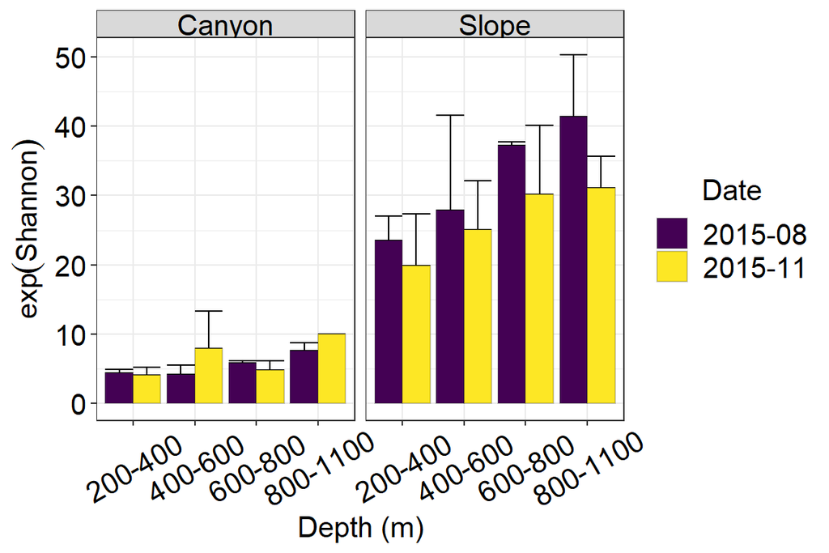

```r
ggplot()+
  geom_errorbar(data=div, aes(x=Zone, y=d1, ymin=d1, ymax=d1+d1.sd, fill=Date), position="dodge")+
  geom_bar(data=div, aes(x=Zone, y=d1, fill=Date), stat="identity", position="dodge", colour=gray(0, 0.2))+
  facet_wrap(~Habitat)+
  labs(x="Depth (m)", y=expression(exp(Shannon)))+
  scale_fill_viridis(discrete = TRUE)+
  scale_color_viridis(discrete = TRUE)+
  theme_bw() %+replace% large %+replace% theme(axis.text.x=element_text(angle=30))
```

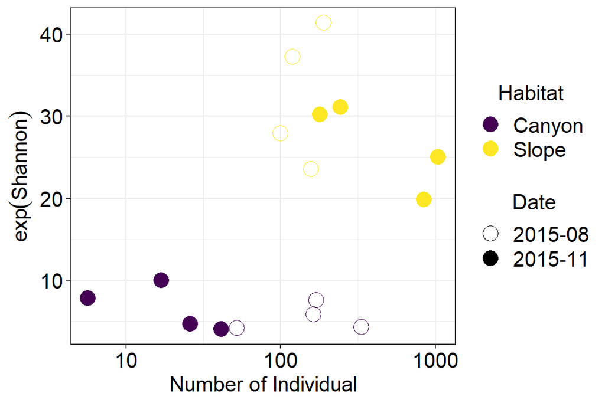

```r
ggplot(data=div, aes(x=Abund, y=d1, colour=Habitat, shape=Date))+
  geom_point(size=5)+
  labs(x="Number of Individual", y=expression(exp(Shannon)))+
  scale_shape_manual(values=c(1, 19))+
  scale_x_log10()+
  scale_color_viridis(discrete = TRUE)+
  theme_bw() %+replace% large
```

## q=2 or inverse Simpson diversity

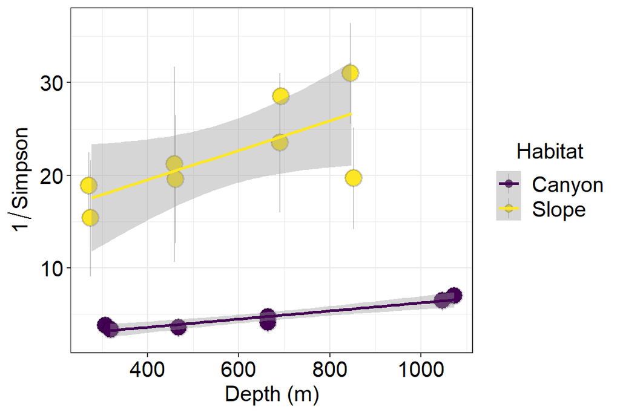

```r
ggplot(data=div,
       aes(x=Depth, y=d2, ymin=d2-d2.sd, ymax=d2+d2.sd, colour=Habitat))+
  geom_pointrange(aes(fill=Habitat), pch=21, colour=gray(0, 0.2), fatten = 10,
                  position=position_jitter(width=10))+
  stat_smooth(method="lm", fill="gray60")+
  labs(x="Depth (m)", y=expression(1/Simpson))+
  scale_fill_viridis(discrete = TRUE)+
  scale_color_viridis(discrete = TRUE)+
  theme_bw() %+replace% large
```

```r
# Linear regression
hl <- splitBy(~Habitat, div)
lapply(hl, FUN=function(x)summary(lm(d2~Depth, data=x)))
```

```
## $Canyon
##
## Call:
## lm(formula = d2 ~ Depth, data = x)
##
## Residuals:
##        1        2        3        4        9       11       12
##  0.58250 -0.39033 -0.01157 -0.03707  0.09684 -0.65791  0.41753
##
## Coefficients:
##              Estimate Std. Error t value Pr(>|t|)
## (Intercept) 1.8186239  0.4365244   4.166 0.008772 **
## Depth       0.0043969  0.0006134   7.168 0.000822 ***
## ---
## Signif. codes:  0 '***' 0.001 '**' 0.01 '*' 0.05 '.' 0.1 ' ' 1
##
## Residual standard error: 0.4711 on 5 degrees of freedom
##   (1 observation deleted due to missingness)
## Multiple R-squared:  0.9113, Adjusted R-squared:  0.8936
## F-statistic: 51.38 on 1 and 5 DF,  p-value: 0.000822
##
##
## $Slope
##
## Call:
## lm(formula = d2 ~ Depth, data = x)
##
## Residuals:
##     Min      1Q  Median      3Q     Max
## -6.9756 -1.2584  0.0146  2.0879  4.4048
##
## Coefficients:
##              Estimate Std. Error t value Pr(>|t|)
## (Intercept) 13.132642   3.955901   3.320   0.0160 *
## Depth        0.015922   0.006489   2.454   0.0496 *
## ---
## Signif. codes:  0 '***' 0.001 '**' 0.01 '*' 0.05 '.' 0.1 ' ' 1
##
## Residual standard error: 3.985 on 6 degrees of freedom
## Multiple R-squared:  0.5008, Adjusted R-squared:  0.4176
## F-statistic:  6.02 on 1 and 6 DF,  p-value: 0.04955
```

```r
# Linear Mixed-Effects Models
f <- lme(fixed = d2 ~ Habitat*Depth, random = ~1|Cruise, data=div, method = "REML", weights=varIdent(form=~1|Cruise), na.action = na.omit)
summary(f)
```

```
## Linear mixed-effects model fit by REML
##  Data: div
##        AIC      BIC    logLik
##   93.05569 95.84096 -39.52785
##
## Random effects:
##  Formula: ~1 | Cruise
##         (Intercept)  Residual
## StdDev:      1.8875 0.9230487
##
## Variance function:
##  Structure: Different standard deviations per stratum
##  Formula: ~1 | Cruise
##  Parameter estimates:
## OR1_1114 OR1_1126
## 1.000000 4.324451
## Fixed effects: d2 ~ Habitat * Depth
##                        Value Std.Error DF  t-value p-value
## (Intercept)         1.005991 1.8614520 10 0.540433  0.6007
## HabitatSlope       10.030605 1.6951037 10 5.917399  0.0001
## Depth               0.004045 0.0016476 10 2.455143  0.0340
## HabitatSlope:Depth  0.017976 0.0026486 10 6.786951  0.0000
##  Correlation:
##                    (Intr) HbttSl Depth
## HabitatSlope       -0.412
## Depth              -0.563  0.610
## HabitatSlope:Depth  0.350 -0.925 -0.622
##
## Standardized Within-Group Residuals:
##         Min          Q1         Med          Q3         Max
## -2.22863465 -0.27923353 -0.01072227  0.46556809  1.23245131
##
## Number of Observations: 15
## Number of Groups: 2
```

```r
# General linear Models
dat <- cbind(div[, c(1:23, 45:46)], es)
dat <- subset(dat, !is.na(d2))
f <- gls(d2 ~ Speed+CN+Salinity+over20+TOC+transmissometer+Temperature, data=dat)
summary(f)
```

```
## Generalized least squares fit by REML
##   Model: d2 ~ Speed + CN + Salinity + over20 + TOC + transmissometer +      Temperature
##   Data: dat
##        AIC      BIC    logLik
##   72.73228 72.24547 -27.36614
##
## Coefficients:
##                     Value Std.Error   t-value p-value
## (Intercept)     13.036296  1.171612 11.126801  0.0000
## Speed           -2.977353  2.897295 -1.027632  0.3383
## CN               1.175638  1.877470  0.626182  0.5511
## Salinity        -0.768100  1.312970 -0.585009  0.5769
## over20           2.145716  2.965550  0.723547  0.4928
## TOC              5.976091  3.923424  1.523183  0.1715
## transmissometer  3.498991  3.369328  1.038483  0.3336
## Temperature      2.006542  1.710734  1.172913  0.2792
##
##  Correlation:
##                 (Intr) Speed  CN     Salnty over20 TOC    trnsms
## Speed           -0.047
## CN               0.235 -0.441
## Salinity        -0.181 -0.331 -0.154
## over20           0.309 -0.403  0.481 -0.001
## TOC             -0.345  0.446 -0.775  0.265 -0.420
## transmissometer  0.386  0.055  0.580 -0.380  0.632 -0.693
## Temperature     -0.344  0.043 -0.408  0.185 -0.605  0.543 -0.680
##
## Standardized residuals:
##         Min          Q1         Med          Q3         Max
## -0.97278158 -0.57274201 -0.07474042  0.28981548  1.52831874
##
## Residual standard error: 4.080262
## Degrees of freedom: 15 total; 7 residual
```

```r
# Model selection
ms <- dredge(f)
kable(ms[1:10,])
```

|  | (Intercept) | CN | over20 | Salinity | Speed | Temperature | TOC | transmissometer | df | logLik | AICc | delta | weight |
| --- | --- | --- | --- | --- | --- | --- | --- | --- | --- | --- | --- | --- | --- |
| 57 | 12.53786 | NA | NA | NA | -3.083436 | 3.246244 | 8.826432 | NA | 5 | -33.98130 | 84.62927 | 0.000000 | 0.27509021 |
| 113 | 12.70040 | NA | NA | NA | NA | 2.557248 | 9.139065 | 2.307743 | 5 | -34.66336 | 85.99339 | 1.364117 | 0.13907878 |
| 49 | 12.44263 | NA | NA | NA | NA | 3.091712 | 11.498001 | NA | 4 | -37.06933 | 86.13865 | 1.509380 | 0.12933541 |
| 121 | 12.63367 | NA | NA | NA | -2.475018 | 2.978137 | 8.304831 | 1.025991 | 6 | -32.29422 | 87.08843 | 2.459163 | 0.08044048 |
| 51 | 12.39226 | NA | -1.3093468 | NA | NA | 3.350219 | 10.649754 | NA | 5 | -35.31075 | 87.28817 | 2.658899 | 0.07279515 |
| 59 | 12.55664 | NA | 0.3409891 | NA | -3.266563 | 3.188100 | 8.888672 | NA | 6 | -32.41345 | 87.32690 | 2.697630 | 0.07139902 |
| 99 | 13.23076 | NA | 2.8543120 | NA | NA | NA | 7.589568 | 4.910599 | 5 | -35.37138 | 87.40942 | 2.780150 | 0.06851304 |
| 50 | 12.47611 | -1.1579460 | NA | NA | NA | 3.111661 | 11.987125 | NA | 5 | -35.50365 | 87.67396 | 3.044688 | 0.06002463 |
| 97 | 13.04371 | NA | NA | NA | NA | NA | 6.737601 | 3.469259 | 4 | -37.94471 | 87.88943 | 3.260157 | 0.05389409 |
| 58 | 12.53785 | 0.0314748 | NA | NA | -3.112640 | 3.247166 | 8.787833 | NA | 6 | -32.78119 | 88.06239 | 3.433115 | 0.04942920 |

```r
# Model averaging
ma <- model.avg(ms, fit=TRUE)
kable(summary(ma)$coefmat.full)
```

|  | Estimate | Std. Error | Adjusted SE | z value | Pr(>\|z\|) |
| --- | --- | --- | --- | --- | --- |
| (Intercept) | 12.7513474 | 1.1086330 | 1.2373638 | 10.3052529 | 0.0000000 |
| Speed | -1.4015404 | 2.1755509 | 2.2980184 | 0.6098909 | 0.5419341 |
| Temperature | 2.1040819 | 1.7089824 | 1.7823283 | 1.1805243 | 0.2377917 |
| TOC | 8.4626290 | 3.2238698 | 3.3931072 | 2.4940647 | 0.0126290 |
| transmissometer | 1.5411507 | 2.4539745 | 2.5533411 | 0.6035820 | 0.5461216 |
| over20 | 0.3639211 | 1.6404629 | 1.7557809 | 0.2072702 | 0.8357988 |
| CN | 0.0565012 | 0.9125623 | 0.9740824 | 0.0580045 | 0.9537450 |
| Salinity | -0.1599696 | 0.6500895 | 0.7018150 | 0.2279370 | 0.8196952 |

```r
# Best model
b <- get.models(ms, subset=1)[[1]]
kable(summary(b)$tTable)
```

|  | Value | Std.Error | t-value | p-value |
| --- | --- | --- | --- | --- |
| (Intercept) | 12.537862 | 0.9237224 | 13.573193 | 0.0000000 |
| Speed | -3.083436 | 1.6194890 | -1.903956 | 0.0833901 |
| Temperature | 3.246244 | 1.0254869 | 3.165564 | 0.0089894 |
| TOC | 8.826432 | 1.8430503 | 4.789035 | 0.0005632 |

```r
# Relative importance
kable(summary(ma)$sw)
```

|  | x |
| --- | --- |
| TOC | 0.9498616 |
| Temperature | 0.7023827 |
| Speed | 0.4654285 |
| transmissometer | 0.4485296 |
| over20 | 0.2951074 |
| CN | 0.2046720 |
| Salinity | 0.1732685 |

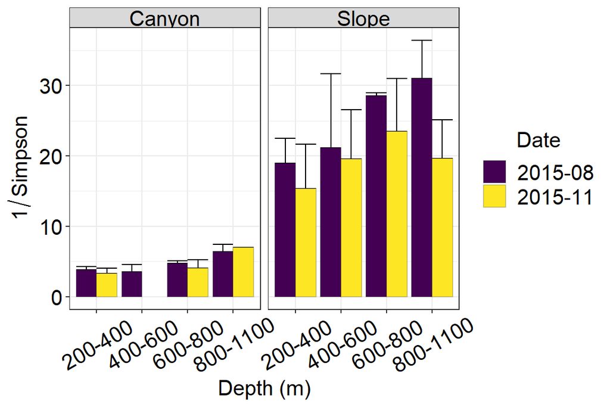

```r
ggplot()+
  geom_errorbar(data=div, aes(x=Zone, y=d2, ymin=d2, ymax=d2+d2.sd, fill=Date), position="dodge")+
  geom_bar(data=div, aes(x=Zone, y=d2, fill=Date), stat="identity", position="dodge", colour=gray(0, 0.2))+
  facet_wrap(~Habitat)+
  labs(x="Depth (m)", y=expression(1/Simpson))+
  scale_fill_viridis(discrete = TRUE)+
  scale_color_viridis(discrete = TRUE)+
  theme_bw() %+replace% large %+replace% theme(axis.text.x=element_text(angle=30))
```

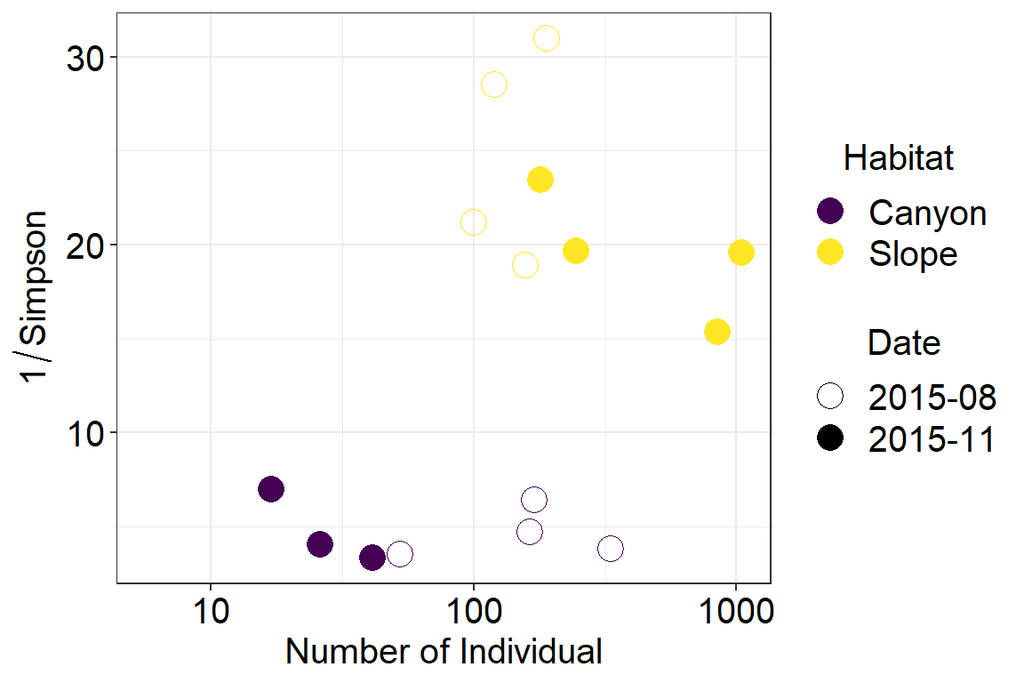

```r
ggplot(data=div, aes(x=Abund, y=d2, colour=Habitat, shape=Date))+
  geom_point(size=5)+
  labs(x="Number of Individual", y=expression(1/Simpson))+
  scale_shape_manual(values=c(1, 19))+
  scale_x_log10()+
  scale_color_viridis(discrete = TRUE)+
  theme_bw() %+replace% large
```

# Correlation bettwen exponential Shannon (q=1) and environmental factor

```r
p1 <- ggplot(data=div,
       aes(x=Speed, y=d1, ymin=d1-d1.sd, ymax=d1+d1.sd))+
  geom_pointrange(aes(fill=Habitat), pch=21, colour=gray(0, 0.2), fatten=10)+
  stat_smooth(method="lm", fill="gray60", colour="gray50")+
  labs(x="Modeled Current Velocity (m/s)", y="Shannon Diversity")+
  scale_fill_viridis(discrete = TRUE)+
  scale_color_viridis(discrete = TRUE)+
  theme_bw() %+replace% large %+replace% theme(legend.position="none")

cor.test(formula=~d1+Speed, data=div)
```

```
##
##  Pearson's product-moment correlation
##
## data:  d1 and Speed
## t = -5.1374, df = 14, p-value = 0.0001509
## alternative hypothesis: true correlation is not equal to 0
## 95 percent confidence interval:
##  -0.9309941 -0.5216518
## sample estimates:
##        cor
## -0.8083337
```

```r
p2 <- ggplot(data=div,
       aes(x=over20, y=d1, ymin=d1.sd, ymax=d1.sd))+
  geom_pointrange(aes(fill=Habitat), pch=21, colour=gray(0, 0.2), fatten=10)+
  stat_smooth(method="lm", fill="gray60", colour="gray50")+
  labs(x="Modeled Duration of Erosion (hr)", y="Shannon Diversity")+
  scale_fill_viridis(discrete = TRUE)+
  scale_color_viridis(discrete = TRUE)+
  theme_bw() %+replace% large %+replace% theme(legend.position="none")

cor.test(formula=~d1+over20, data=div)
```

```
##
##  Pearson's product-moment correlation
##
## data:  d1 and over20
## t = -3.2722, df = 14, p-value = 0.005561
## alternative hypothesis: true correlation is not equal to 0
## 95 percent confidence interval:
##  -0.8700823 -0.2413675
## sample estimates:
##        cor
## -0.6583081
```

```r
p3 <- ggplot(data=div,
       aes(x=transmissometer, y=d1, ymin=d1.sd, ymax=d1.sd))+
  geom_pointrange(aes(fill=Habitat), pch=21, colour=gray(0, 0.2), fatten=10)+
  stat_smooth(method="lm", fill="gray60", colour="gray50")+
  labs(x="Light Transmission (%)", y="")+
  scale_fill_viridis(discrete = TRUE)+
  scale_color_viridis(discrete = TRUE)+
  theme_bw() %+replace% large %+replace% theme(legend.position="none")

cor.test(formula=~d1+transmissometer, data=div)
```

```
##
##  Pearson's product-moment correlation
##
## data:  d1 and transmissometer
## t = 5.6207, df = 14, p-value = 6.31e-05
## alternative hypothesis: true correlation is not equal to 0
## 95 percent confidence interval:
##  0.5732749 0.9401779
## sample estimates:
##       cor
## 0.8324254
```

```r
p4 <- ggplot(data=div,
       aes(x=TOC, y=d1, ymin=d1.sd, ymax=d1.sd))+
  geom_pointrange(aes(fill=Habitat), pch=21, colour=gray(0, 0.2), fatten=10)+
  stat_smooth(method="lm", fill="gray60", colour="gray50")+
  labs(x="Total Organic Carbon (%)", y="")+
  scale_fill_viridis(discrete = TRUE)+
  scale_color_viridis(discrete = TRUE)+
  theme_bw() %+replace% large %+replace% theme(legend.position="none")

cor.test(formula=~d1+TOC, data=div)
```

```
##
##  Pearson's product-moment correlation
##
## data:  d1 and TOC
## t = 6.6347, df = 14, p-value = 1.124e-05
## alternative hypothesis: true correlation is not equal to 0
## 95 percent confidence interval:
##  0.6605280 0.9545758
## sample estimates:
##       cor
## 0.8710333
```

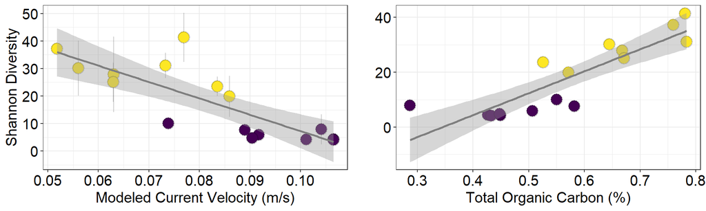

```r
plot_grid(p1, p4, ncol=2, align = "h", axis="b")
```

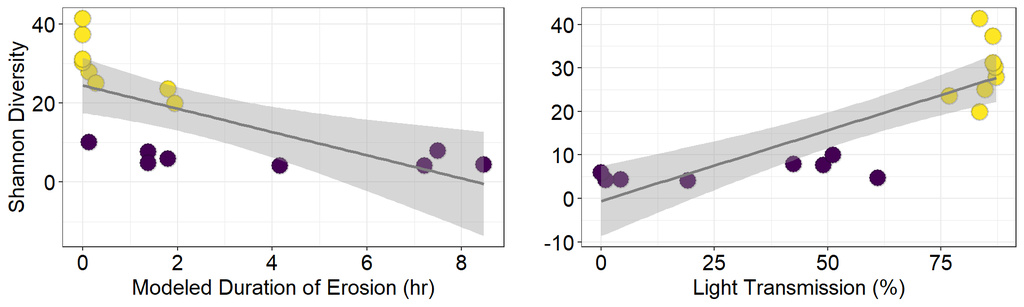

```r
plot_grid(p2, p3, ncol=2, align = "h", axis="b")
```

```r
names(div)[5:7] <- c("0D", "1D", "2D")
names(div)[9:12] <- c("0D.sd", "1D.sd", "2D.sd", "n")
kable(div[,1:12])
```

| Cruise | Station | Deployment | S.obs | 0D | 1D | 2D | S.obs.sd | 0D.sd | 1D.sd | 2D.sd | n |
| --- | --- | --- | --- | --- | --- | --- | --- | --- | --- | --- | --- |
| OR1_1114 | GC1 | 2 | 10.333333 | 5.044333 | 4.340000 | 3.799333 | 1.154700 | 0.5664453 | 0.4900786 | 0.4334932 | 3 |
| OR1_1114 | GC2 | 1 | 8.666667 | 5.051667 | 4.162000 | 3.530000 | 2.886751 | 1.6741736 | 1.2831177 | 1.0488641 | 3 |
| OR1_1114 | GC3 | 1 | 15.333333 | 7.609667 | 5.844333 | 4.687000 | 1.527525 | 0.1904215 | 0.2993164 | 0.4304289 | 3 |
| OR1_1114 | GC4 | 1 | 15.000000 | 9.224000 | 7.602000 | 6.402667 | 1.732051 | 1.3414723 | 1.1495617 | 1.0471339 | 3 |
| OR1_1114 | GS1 | 1 | 34.333333 | 29.899333 | 23.530667 | 18.911333 | 3.511885 | 4.7629195 | 3.4796423 | 3.5620248 | 3 |
| OR1_1114 | GS2 | 1 | 35.666667 | 37.067333 | 27.878333 | 21.163333 | 15.373137 | 18.0976182 | 13.7723390 | 10.5275511 | 3 |
| OR1_1114 | GS3 | 1 | 44.000000 | 48.809667 | 37.214333 | 28.523667 | 2.645751 | 1.2724093 | 0.5531784 | 0.4451812 | 3 |
| OR1_1114 | GS4 | 1 | 48.000000 | 54.342333 | 41.369667 | 30.976667 | 5.196152 | 11.5947815 | 8.9482463 | 5.4122922 | 3 |
| OR1_1126 | GC1 | 1 | 8.333333 | 5.269000 | 4.045000 | 3.313667 | 2.081666 | 1.8636523 | 1.1184065 | 0.7470939 | 3 |
| OR1_1126 | GC2 | 1 | 4.000000 | 6.638333 | 7.861000 | NA | 1.000000 | 4.0120309 | 5.4285158 | NA | 3 |
| OR1_1126 | GC3 | 1 | 6.333333 | 5.596333 | 4.711667 | 4.040667 | 2.309401 | 1.6827597 | 1.4319917 | 1.2075766 | 3 |
| OR1_1126 | GC4 | 3 | 9.000000 | 13.219000 | 9.976000 | 6.954000 | NA | NA | NA | NA | 1 |
| OR1_1126 | GS1 | 1 | 32.000000 | 26.753667 | 19.868000 | 15.354333 | 6.244998 | 9.1817361 | 7.4757539 | 6.2717982 | 3 |
| OR1_1126 | GS2 | 1 | 36.666667 | 32.665333 | 25.002000 | 19.556333 | 5.859465 | 8.2876435 | 7.1758573 | 6.9579645 | 3 |
| OR1_1126 | GS3 | 2 | 39.666667 | 40.076333 | 30.185000 | 23.473333 | 6.658328 | 14.3105101 | 9.9867666 | 7.4935269 | 3 |
| OR1_1126 | GS4 | 1 | 40.000000 | 53.711000 | 31.103000 | 19.659000 | 3.000000 | 4.5137059 | 4.5842007 | 5.4827099 | 3 |